# SMI Data File ReadMe

NanoString Technologies

### This ReadMe describes the data structures of AtoMx™ exported results for the example [CosMx™ Whole Transcriptome (WTx) pancreas dataset](https://nanostring.com/products/cosmx-spatial-molecular-imager/ffpe-dataset/cosmx-smi-human-pancreas-ffpe-dataset/). The exact file structures of your data might have minor difference from the example shown here depending on the version of AtoMx™ software.

# Transcript File

Pancreas_tx_file.csv : 5.2 GB

| fov | cell_ID | cell | x_local_px | y_local_px | x_global_px | y_global_px | z | target | CellComp |
| --- | --- | --- | --- | --- | --- | --- | --- | --- | --- |
| 51 | 675 | c_1_51_675 | 783 | 1005 | 53222.04 | 40920.41 | 4 | CPA1 | Nuclear |
| 51 | 675 | c_1_51_675 | 785 | 1005 | 53224.04 | 40920.41 | 5 | CELA3B | Nuclear |
| 51 | 675 | c_1_51_675 | 786 | 1005 | 53225.04 | 40920.41 | 4 | SPINK1 | Nuclear |
| 51 | 675 | c_1_51_675 | 786 | 1005 | 53225.04 | 40920.41 | 6 | CELA3B | Nuclear |
| 51 | 675 | c_1_51_675 | 787 | 1043 | 53226.04 | 40882.41 | 5 | CELA3B | Cytoplasm |
| 51 | 675 | c_1_51_675 | 787 | 1043 | 53226.04 | 40882.41 | 6 | CELA3B | Cytoplasm |
| 51 | 675 | c_1_51_675 | 787 | 1046 | 53226.04 | 40879.41 | 1 | CELA3B | Cytoplasm |
| 51 | 675 | c_1_51_675 | 784 | 1047 | 53223.04 | 40878.41 | 6 | AKR7A2 | Cytoplasm |
| 51 | 680 | c_1_51_680 | 1672 | 1075 | 54111.04 | 40850.41 | 7 | P4HA2 | Membrane |
| 51 | 680 | c_1_51_680 | 1665 | 1076 | 54104.04 | 40849.41 | 5 | UAP1 | Membrane |

- **Column descriptions:**
  - **fov**
    - The Field Of View (FOV) the transcript is in. All FOVs from the sample are contained within this transcript file.
  - **cell_ID**
    - Unique identifier for a single cell within a given FOV. Transcripts not assigned to cells have a value of 0.
  - **cell**
    - Unique identifier for a single cell within the whole sample. Format ‘c_SLIDENUMBER_FOVNUMBER_CELLID’.
  - **x_local_px**
    - The x position of this transcript within the FOV, measured in pixels. To convert to microns multiply the pixel value by 0.12028 um per pixel.
  - **y_local_px**
    - Same as “x_local_px” but for the y dimension
  - **x_global_px**
    - See “x_local_px” description. The global positions describes the relative position of this transcript within the large sample reference frame.
  - **y_global_px**
    - Same as “x_global_px” but for the y dimension
  - **z**
    - The Z-slice image number. This has an arbitrary unit. Higher numbers are closer to slide surface.
  - **target**
    - The gene detected.
  - **CellComp**
    - The subcellular compartment (Nuclear, Membrane, or Cytoplasmic. Blank denotes Extracellular) in which the transcript was detected as determined by cell segmentation algorithm.

# Cell Expression File

Pancreas_exprMat_file.csv : 2.1 GB

| fov | cell_ID | A1BG | ANXA5 | ARF1 | CPAMD8 | CPB1 | RPS5 | RPS6 | ZZZ3 | Negative1 | Negative2 | SystemControl1 | SystemControl2 | … |
| --- | --- | --- | --- | --- | --- | --- | --- | --- | --- | --- | --- | --- | --- | --- |
| 51 | 999 | 0 | 0 | 0 | 16 | 6 | 0 | 0 | 0 | 0 | 0 | 0 | 0 | … |
| 51 | 1000 | 0 | 0 | 0 | 2 | 7 | 0 | 2 | 0 | 0 | 0 | 0 | 0 | … |
| 51 | 1001 | 0 | 0 | 2 | 5 | 1 | 0 | 0 | 0 | 0 | 0 | 0 | 0 | … |
| 51 | 1002 | 0 | 0 | 1 | 16 | 14 | 1 | 2 | 0 | 0 | 0 | 0 | 0 | … |
| 51 | 1003 | 0 | 2 | 2 | 32 | 31 | 4 | 4 | 0 | 0 | 0 | 0 | 0 | … |
| 51 | 1004 | 0 | 0 | 0 | 17 | 31 | 2 | 0 | 0 | 0 | 0 | 0 | 0 | … |
| 51 | 1005 | 0 | 0 | 6 | 26 | 22 | 0 | 8 | 0 | 0 | 0 | 0 | 0 | … |
| 51 | 1006 | 0 | 0 | 2 | 20 | 50 | 0 | 2 | 0 | 0 | 0 | 0 | 0 | … |
| 51 | 1007 | 0 | 0 | 2 | 13 | 7 | 0 | 2 | 0 | 0 | 0 | 0 | 0 | … |
| 51 | 1008 | 0 | 0 | 0 | 12 | 3 | 0 | 0 | 0 | 0 | 0 | 0 | 0 | … |

- **Column descriptions:**
  - **fov**
    - The Field Of View (FOV) the transcript is in. All FOVs from the sample are contained within this Cell Expression file.
  - **cell_ID**
    - Unique identifier for a single cell within a given FOV. To make a unique identifier for a cell within the whole sample use both the “fov” and “cell_ID” columns. All transcripts not assigned to a cell are show with a “cell_ID” value of 0.
  - **Gene expression target (AATK, ABL1, …, etc)**
    - The number of transcripts observed for a given gene target for a given cell.
  - **Negative probes (i.e. Negative##)**
    - Negative probes, which do not match any sequence within the transcriptome or genome, are included. These can be used to assess background levels.
  - **System Control codes (i.e. SystemControl##)**
    - System Control codes and codes which do not have any physical probe associated with them.

# Cell Metadata File

Pancreas_metadata_file.csv : 11.4 MB

| fov | Area | AspectRatio | CenterX_local_px | CenterY_local_px | Width | Height | Mean.PanCK | Max.PanCK | Mean.CD68_CK8_18 | Max.CD68_CK8_18 | Mean.CD298_B2M | Max.CD298_B2M | Mean.CD45 | Max.CD45 | Mean.DAPI | Max.DAPI | cell_id | X | version | Run_name | Run_Tissue_name | tissue | Panel | assay_type | slide_ID | CenterX_global_px | CenterY_global_px | cell_ID | unassignedTranscripts | … |
| --- | --- | --- | --- | --- | --- | --- | --- | --- | --- | --- | --- | --- | --- | --- | --- | --- | --- | --- | --- | --- | --- | --- | --- | --- | --- | --- | --- | --- | --- | --- |
| 51 | 5997 | 1.39 | 141 | 36 | 103 | 74 | 1565 | 5576 | 1701 | 6376 | 2799 | 8980 | 221 | 996 | 1155 | 3476 | c_1_51_1 | 1 | v6 | Slide_S1 | Pancreas | Pancreas | WTX | RNA | 1 | 52580.04 | 41889.41 | 1 | 0.0781346 | … |
| 51 | 1976 | 2.47 | 272 | 17 | 89 | 36 | 594 | 2260 | 154 | 636 | 930 | 1864 | 108 | 360 | 1126 | 2652 | c_1_51_2 | 1 | v6 | Slide_S1 | Pancreas | Pancreas | WTX | RNA | 1 | 52711.04 | 41908.41 | 2 | 0.0781346 | … |
| 51 | 2664 | 1.34 | 363 | 26 | 71 | 53 | 989 | 2812 | 135 | 728 | 1134 | 2400 | 92 | 320 | 794 | 1884 | c_1_51_3 | 1 | v6 | Slide_S1 | Pancreas | Pancreas | WTX | RNA | 1 | 52802.04 | 41899.41 | 3 | 0.0781346 | … |
| 51 | 8611 | 1.42 | 469 | 45 | 129 | 91 | 10538 | 43016 | 141 | 1068 | 4504 | 13796 | 115 | 896 | 1039 | 3324 | c_1_51_4 | 1 | v6 | Slide_S1 | Pancreas | Pancreas | WTX | RNA | 1 | 52908.04 | 41880.41 | 4 | 0.0781346 | … |
| 51 | 5409 | 1.01 | 572 | 40 | 83 | 82 | 1452 | 9876 | 107 | 720 | 1327 | 11060 | 90 | 708 | 1988 | 3800 | c_1_51_5 | 1 | v6 | Slide_S1 | Pancreas | Pancreas | WTX | RNA | 1 | 53011.04 | 41885.41 | 5 | 0.0781346 | … |
| 51 | 4116 | 2.68 | 726 | 21 | 118 | 44 | 4687 | 23108 | 285 | 18592 | 4824 | 15556 | 212 | 11168 | 1906 | 3228 | c_1_51_6 | 1 | v6 | Slide_S1 | Pancreas | Pancreas | WTX | RNA | 1 | 53165.04 | 41904.41 | 6 | 0.0781346 | … |
| 51 | 5768 | 1.26 | 822 | 38 | 97 | 77 | 570 | 6304 | 106 | 2940 | 1418 | 20916 | 74 | 2864 | 1666 | 3576 | c_1_51_7 | 1 | v6 | Slide_S1 | Pancreas | Pancreas | WTX | RNA | 1 | 53261.04 | 41887.41 | 7 | 0.0781346 | … |
| 51 | 2859 | 1.98 | 1908 | 25 | 103 | 52 | 11695 | 36072 | 212 | 540 | 14515 | 50412 | 134 | 536 | 2029 | 3196 | c_1_51_8 | 1 | v6 | Slide_S1 | Pancreas | Pancreas | WTX | RNA | 1 | 54347.04 | 41900.41 | 8 | 0.0781346 | … |
| 51 | 3831 | 1.65 | 2171 | 27 | 91 | 55 | 435 | 1224 | 456 | 1588 | 2740 | 7148 | 51 | 420 | 965 | 4256 | c_1_51_9 | 1 | v6 | Slide_S1 | Pancreas | Pancreas | WTX | RNA | 1 | 54610.04 | 41898.41 | 9 | 0.0781346 | … |
| 51 | 5162 | 1.71 | 2303 | 28 | 99 | 58 | 144 | 1512 | 90 | 1480 | 342 | 2592 | 53 | 464 | 2100 | 5264 | c_1_51_10 | 1 | v6 | Slide_S1 | Pancreas | Pancreas | WTX | RNA | 1 | 54742.04 | 41897.41 | 10 | 0.0781346 | … |

- **Column descriptions:**
  - **fov**
    - The Field Of View (FOV) the transcript is in. All FOVs from the sample are contained within this Cell Metadata file.
  - **Area**
    - Number of pixels assigned to a given cell.
  - **Aspect Ratio**
    - width divided by height.
  - **CenterX_local_px**
    - The x position of this transcript within the FOV, measured in pixels. The pixel edge length is 120nm. Thus, to convert to microns multiply the pixel value by 0.12028 um per pixel.
  - **CenterY_local_px**
    - Same as “CenterX_local_px” but for the y dimension
  - **Width**
    - Cell’s maximum length in x dimension (pixels)
  - **Height**
    - Cell’s maximum length in y dimension (pixels)
  - **Mean.PanCK**
    - Mean fluorescence intensity for a given cell.
  - **Max.PanCK**
    - Maximum fluorescence intensity for a given cell.
  - **Mean.CD68_CK8_18**
    - Mean fluorescence intensity for a given cell.
  - **Max.CD68_CK8_18**
    - Maximum fluorescence intensity for a given cell.
  - **Mean.CD298_B2M**
    - Mean fluorescence intensity for a given cell.
  - **Max.CD298_B2M**
    - Maximum fluorescence intensity for a given cell.
  - **Mean.CD45**
    - Mean fluorescence intensity for a given cell.
  - **Max.CD45**
    - Maximum fluorescence intensity for a given cell.
  - **Mean.DAPI**
    - Mean fluorescence intensity for a given cell.
  - **Max.DAPI**
    - Maximum fluorescence intensity for a given cell.
  - **cell_id**
    - Unique identifier for a single cell within a given FOV.
  - **CenterX_global_px**
    - See “CenterX_local_px” description. The global positions describes the relative position of this transcript within the large sample reference frame.
  - **CenterY_global_px**
    - Same as “CenterX_global_px” but for the y dimension
  - **unassignedTranscripts**
    - Fraction of transcripts in the FOV the cell resides in that are not assigned within any cell.
  - **nCount_RNA**
    - Total RNA transcripts observed.
  - **nFeature_RNA**
    - Total number of unique RNA transcripts observed.
  - **nCount_negprobes**
    - Total Negative Control Probe counts observed.
  - **nFeature_negprobes**
    - Total number of unique Negative Control Probe counts observed.
  - **nCount_falsecode**
    - Total System Control codes counts observed. These codes do not have a physical probe in the experiment.
  - **nFeature_falsecode**
    - Total number of unique System Control codes counts observed.
  - **Area.um2**
    - Cell area in square microns.
  - **cell**
    - Unique identifier for a single cell within the whole sample. Format ‘c_SLIDENUMBER_FOVNUMBER_CELLID’.
  - **Additional columns are also included with sample specific descriptions and metrics**

# FOV Positions File

##### This file is used to reference each FOV within the global structure of the sample.

Pancreas_fov_positions_file.csv : 1.3 kB

| Slide | X_mm | Y_mm | Z_mm | ZOffset_mm | ROI | FOV | Order | Run_Tissue_name |
| --- | --- | --- | --- | --- | --- | --- | --- | --- |
| 1 | 6.307417 | 5.042828 | -0.034417 | -2 | 0 | 51 | 67 | Pancreas |
| 1 | 6.307417 | 4.530908 | -0.034663 | -2 | 0 | 52 | 66 | Pancreas |
| 1 | 6.307417 | 4.018988 | -0.034878 | -2 | 0 | 53 | 65 | Pancreas |
| 1 | 6.819338 | 4.018988 | -0.034577 | -2 | 0 | 54 | 64 | Pancreas |
| 1 | 6.819338 | 4.530908 | -0.034365 | -2 | 0 | 55 | 63 | Pancreas |
| 1 | 6.819338 | 5.042828 | -0.034124 | -2 | 0 | 56 | 62 | Pancreas |
| 1 | 7.331259 | 5.042828 | -0.033824 | -2 | 0 | 57 | 61 | Pancreas |
| 1 | 7.331259 | 4.530908 | -0.034063 | -2 | 0 | 58 | 60 | Pancreas |
| 1 | 7.331259 | 4.018988 | -0.034271 | -2 | 0 | 59 | 59 | Pancreas |
| 1 | 6.190926 | 1.023840 | -0.035615 | -2 | 0 | 60 | 50 | Pancreas |

- **Column descriptions:**
  - **FOV**
    - The Field Of View (FOV) number.
  - **X_mm**
    - The relative x position of the FOV, measured in millimeters.
  - **Y_mm**
    - See “X_mm” description, but in for the y dimension.
  - **Z_mm**
    - The relative z position of the FOV, measured in millimeters.
  - **ZOffset_mm**
    - Z offset in millimeters.
  - **Order**
    - Order in which the FOVs were collected.
  - **Run_Tissue_name**
    - Name of the slide
  - **Slide**
    - Slide number
  - **ROI**
    - Region of Interest

##### In latest version of AtoMx exported files, FOV postion file may also contain coordinates in px units.

# Cell Polygons File

##### This file is a simple polygon descripton of cell boundries. These are provided as a graphical convenience but are only approximations of the cell boundries, which are fully defined by the cellLabels mask images.

Pancreas-polygons.csv : 66.3 MB

| fov | cellID | cell | x_local_px | y_local_px | x_global_px | y_global_px |
| --- | --- | --- | --- | --- | --- | --- |
| 51 | 1 | c_1_51_1 | 190 | 0 | 52629.04 | 41925.41 |
| 51 | 1 | c_1_51_1 | 191 | 1 | 52630.04 | 41924.41 |
| 51 | 1 | c_1_51_1 | 192 | 6 | 52631.04 | 41919.41 |
| 51 | 1 | c_1_51_1 | 192 | 9 | 52631.04 | 41916.41 |
| 51 | 1 | c_1_51_1 | 178 | 66 | 52617.04 | 41859.41 |
| 51 | 1 | c_1_51_1 | 177 | 67 | 52616.04 | 41858.41 |
| 51 | 1 | c_1_51_1 | 152 | 73 | 52591.04 | 41852.41 |
| 51 | 1 | c_1_51_1 | 147 | 73 | 52586.04 | 41852.41 |
| 51 | 1 | c_1_51_1 | 108 | 56 | 52547.04 | 41869.41 |
| 51 | 1 | c_1_51_1 | 106 | 55 | 52545.04 | 41870.41 |

- **Column descriptions:**
  - **fov**
    - The Field Of View (FOV) number.
  - **cell_ID**
    - Unique identifier for a single cell within a given FOV.
  - **cell**
    - Unique identifier for a single cell within the whole sample. Format ‘c_SLIDENUMBER_FOVNUMBER_CELLID’.
  - **x_local_px**
    - The x position of this transcript within the FOV, measured in pixels. To convert to microns multiply the pixel value by 0.12028 um per pixel.
  - **y_local_px**
    - Same as “x_local_px” but for the y dimension
  - **x_global_px**
    - The relative x position of the FOV, measured in pixels. To convert to microns multiply the pixel value by 0.12028 um per pixel. All FOVs are the same dimension, 4256 x 4256 pixels.
  - **y_global_px**
    - See “x_global_px” description, but in for the y dimension.

# CellComposite Images

##### Each FOV has a CellComposite image that displays the ImmunoFluorescence intesity from the IHC markers selected for the SMI experiment.

##### CellComposite images are not included in AtoMx v1.3 software.

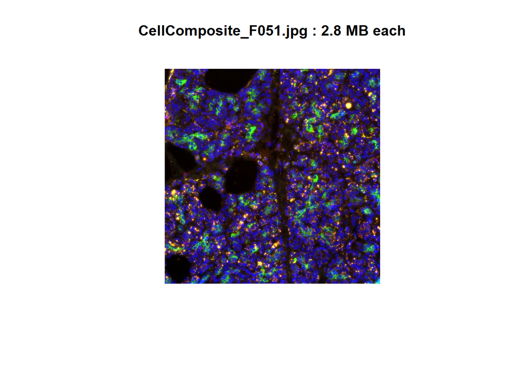

# CellOverlay Images

##### Each FOV has a CellOverlay image that displays the cell boundries determined during cell segmentation, shown as cyan lines.

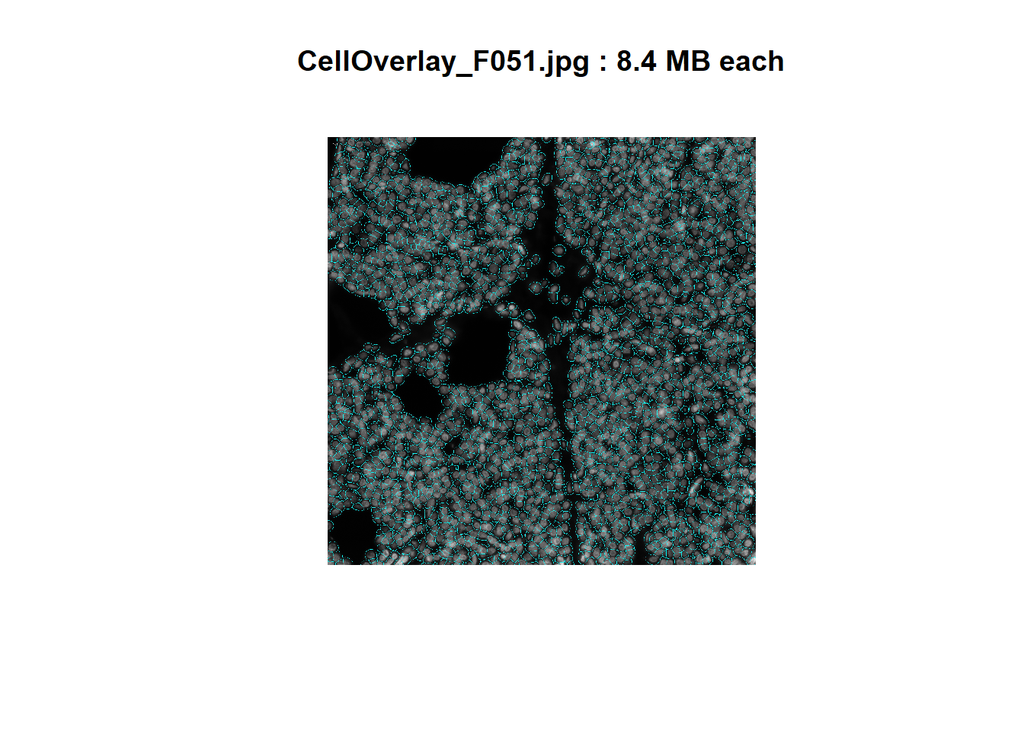

# CellLabels Images

##### Each FOV has a CellLabels image that displays the cell definitions determined during cell segmentation. Each cell identified is given a unique number (cell_ID) and all pixels determined to be within that cell have an intensity value matching that number. These cell_ID values are shared in the transcript, Cell Expression, and Cell Metadata files. A pixel not assigned to a cell has a “0” value. To view this image we recommend opening in ImageJ or similar software that allows for brighness/contrast adjustments.

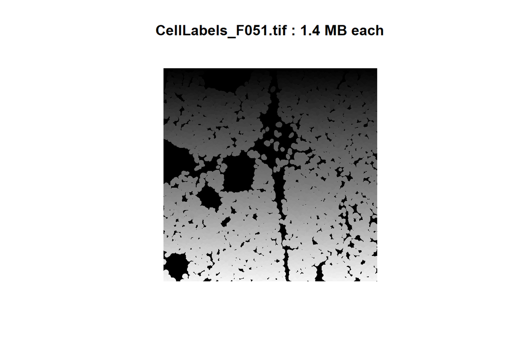

# CompartmentLabels Images

##### Each FOV has a CompartmentLabels image that displays the subcellular compartment definitions determined during cell segmentation. Each compartment type is given a unique number and all pixels determined to be within that compartment type have an intensity value matching that number. To view this image we recommend opening in ImageJ or similar software that allows for brighness/contrast adjustments.

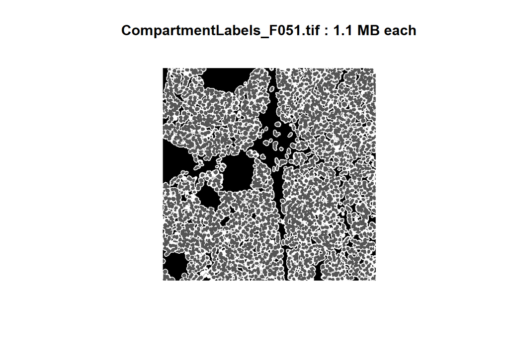

- **Compartment types**
  0. **Extracellular**
  1. **Nuclear**
  2. **Membrane**
  3. **Cytoplasmic**

# Seurat object

##### A preloaded Seurat object is also supplied. This object is compatible with the latest Seruat version (V5).

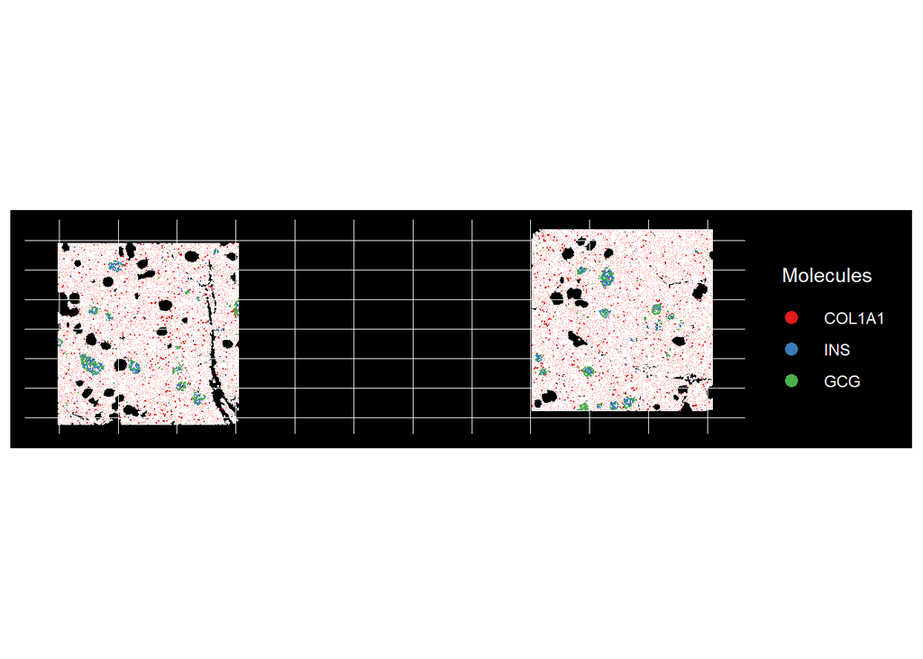

Pancreas WTx

```r
# Seurat ---------------------------------------------------------------------------
# packageVersion("Seurat")
# [1] ‘5.0.1’
library(Seurat)
library(SeuratObject)
panc <- readRDS("~/../Downloads/Seurat_Pancreas_withTranscripts.rds")

# check common plot types
Seurat::ImageDimPlot(object = panc, boundaries = "segmentation", molecules = c("COL1A1", "INS", "GCG"))
```

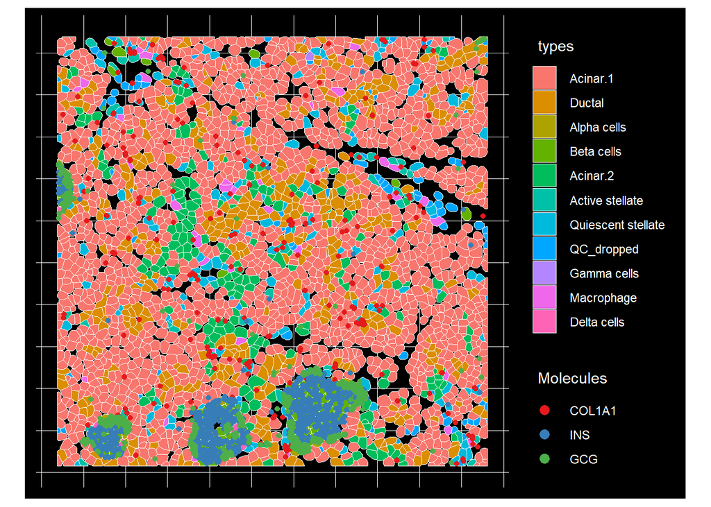

Pancreas WTx, single FOV

```r
# add cell typing results from InSituType
meta <- readRDS("~/../Downloads/Pancreas_celltype_InSituType.rds")
panc@meta.data$types <- meta[rownames(panc@meta.data), "cell_types"]
panc@meta.data$types[is.na(panc@meta.data$types)] <- "QC_dropped"

# zoom to single FOV
fox <- apply(panc@images$Pancreas$centroids@coords[panc@meta.data$fov %in% 52, ], 2, range)
options(future.globals.maxSize = 8000 * 1024^2)
zoom.crop <- Crop(panc[["Pancreas"]], x = fox[,"y"], y = fox[,"x"])
panc[["zoom1"]] <- zoom.crop
DefaultBoundary(panc[["zoom1"]]) <- "segmentation"
Seurat::ImageDimPlot(object = panc, fov = "zoom1", molecules = c("COL1A1", "INS", "GCG"), group.by = "types", mols.size = 1.5)
```